# dada2 analysis for blue-jam project

jen nguyen

10/14/2021

Samples collected on 2021-07-23 and 2021-07-30 were re-sequenced by Gut4Health (different library prep from first sequencing run). This R Markdown file analyses those new sequences, received by Jen on October 7, 2021.

Differences between this sequencing run and the last:

1. The re-sequenced data is named Jen01 etc, while the data from the first sequencing run is named JN01.
2. The forward and reverse reads in the re-sequenced data together span V3V4 (~443 bp) instead of only V4 (~254bp).

```r
library(dada2); packageVersion("dada2")
```

```
[1] ‘1.20.0’
```

```r
library(ggplot2)
library(here)
library(phyloseq)
library(Biostrings)
library(tidyverse)
library(fs)
```

```r
#path_raw <- here::here("data/reads/raw")
path_raw <- here::here("Documents/TropiniLab/Data/Sequencing/2021-10-07/raw")
path_filtered <- here::here("Documents/TropiniLab/Data/Sequencing/2021-10-07/filtered")
list.files(path_raw)
```

```
 [1] "Jen01_S121_R1_001.fastq.gz" "Jen01_S121_R2_001.fastq.gz"
 [3] "Jen02_S122_R1_001.fastq.gz" "Jen02_S122_R2_001.fastq.gz"
 [5] "Jen03_S123_R1_001.fastq.gz" "Jen03_S123_R2_001.fastq.gz"
 [7] "Jen04_S124_R1_001.fastq.gz" "Jen04_S124_R2_001.fastq.gz"
 [9] "Jen05_S125_R1_001.fastq.gz" "Jen05_S125_R2_001.fastq.gz"
[11] "Jen06_S126_R1_001.fastq.gz" "Jen06_S126_R2_001.fastq.gz"
[13] "Jen07_S127_R1_001.fastq.gz" "Jen07_S127_R2_001.fastq.gz"
[15] "Jen08_S128_R1_001.fastq.gz" "Jen08_S128_R2_001.fastq.gz"
[17] "Jen09_S129_R1_001.fastq.gz" "Jen09_S129_R2_001.fastq.gz"
[19] "Jen10_S130_R1_001.fastq.gz" "Jen10_S130_R2_001.fastq.gz"
[21] "Jen11_S131_R1_001.fastq.gz" "Jen11_S131_R2_001.fastq.gz"
[23] "Jen12_S132_R1_001.fastq.gz" "Jen12_S132_R2_001.fastq.gz"
[25] "Jen13_S133_R1_001.fastq.gz" "Jen13_S133_R2_001.fastq.gz"
[27] "Jen14_S134_R1_001.fastq.gz" "Jen14_S134_R2_001.fastq.gz"
[29] "Jen15_S135_R1_001.fastq.gz" "Jen15_S135_R2_001.fastq.gz"
[31] "Jen16_S136_R1_001.fastq.gz" "Jen16_S136_R2_001.fastq.gz"
[33] "Jen17_S137_R1_001.fastq.gz" "Jen17_S137_R2_001.fastq.gz"
[35] "Jen18_S138_R1_001.fastq.gz" "Jen18_S138_R2_001.fastq.gz"
[37] "mock2_S139_R1_001.fastq.gz" "mock2_S139_R2_001.fastq.gz"
[39] "NTC2_S120_R1_001.fastq.gz"  "NTC2_S120_R2_001.fastq.gz"
```

```r
# Forward and reverse fastq filenames have format: SAMPLENAME_R1_001.fastq and SAMPLENAME_R2_001.fastq
fnFs <- sort(list.files(path_raw, pattern="_R1_001.fastq", full.names = TRUE))
fnRs <- sort(list.files(path_raw, pattern="_R2_001.fastq", full.names = TRUE))
fnFs %>% path_file %>% head
```

```
[1] "Jen01_S121_R1_001.fastq.gz" "Jen02_S122_R1_001.fastq.gz" "Jen03_S123_R1_001.fastq.gz"
[4] "Jen04_S124_R1_001.fastq.gz" "Jen05_S125_R1_001.fastq.gz" "Jen06_S126_R1_001.fastq.gz"
```

```r
# Extract sample names, assuming filenames have format: SAMPLENAME_XXX.fastq
sample.names <- sapply(strsplit(basename(fnFs), "_"), `[`, 1)
print(sample.names)
```

```
 [1] "Jen01" "Jen02" "Jen03" "Jen04" "Jen05" "Jen06" "Jen07" "Jen08" "Jen09" "Jen10"
[11] "Jen11" "Jen12" "Jen13" "Jen14" "Jen15" "Jen16" "Jen17" "Jen18" "mock2" "NTC2"
```

```
`guides(<scale> = FALSE)` is deprecated. Please use `guides(<scale> = "none")` instead.
```

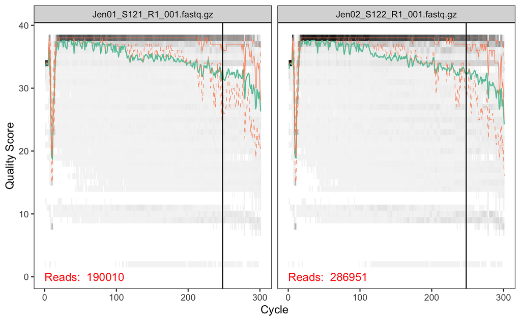

```r
plotQualityProfile(fnFs[1:2]) +
  geom_vline(xintercept = 248) # truncation length of forward reads
```

```
`guides(<scale> = FALSE)` is deprecated. Please use `guides(<scale> = "none")` instead.
```

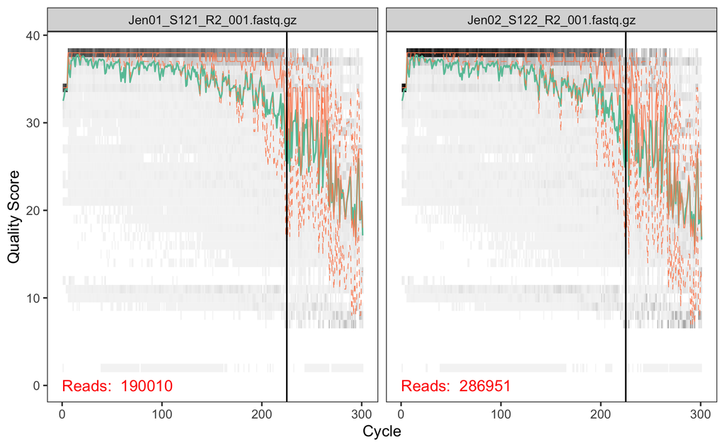

```r
plotQualityProfile(fnRs[1:2]) +
  geom_vline(xintercept = 225) # truncation length of reverse reads
```

```
`guides(<scale> = FALSE)` is deprecated. Please use `guides(<scale> = "none")` instead.
```

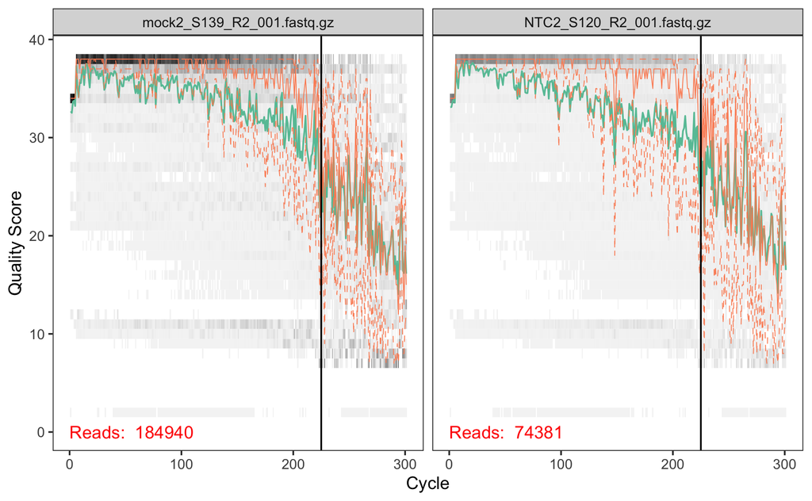

```r
plotQualityProfile(tail(fnRs,2)) +
  geom_vline(xintercept = 225) # truncation length of reverse reads
```

```r
filtFs <- file.path(path_filtered, paste0(sample.names, "_F_filt.fastq.gz"))
filtRs <- file.path(path_filtered, paste0(sample.names, "_R_filt.fastq.gz"))
names(filtFs) <- sample.names
names(filtRs) <- sample.names
```

```r
out <- filterAndTrim(fnFs, filtFs, fnRs, filtRs, truncLen=c(248,225),
              maxN=0, maxEE=c(2,2), truncQ=2, rm.phix=TRUE,
              compress=TRUE, multithread=TRUE) # On Windows set multithread=FALSE
```

Much higher read yield than the first sequencing run, which had many samples in the low thousands!

```r
errF <- learnErrors(filtFs, multithread=TRUE)
```

```r
errR <- learnErrors(filtRs, multithread=TRUE)
```

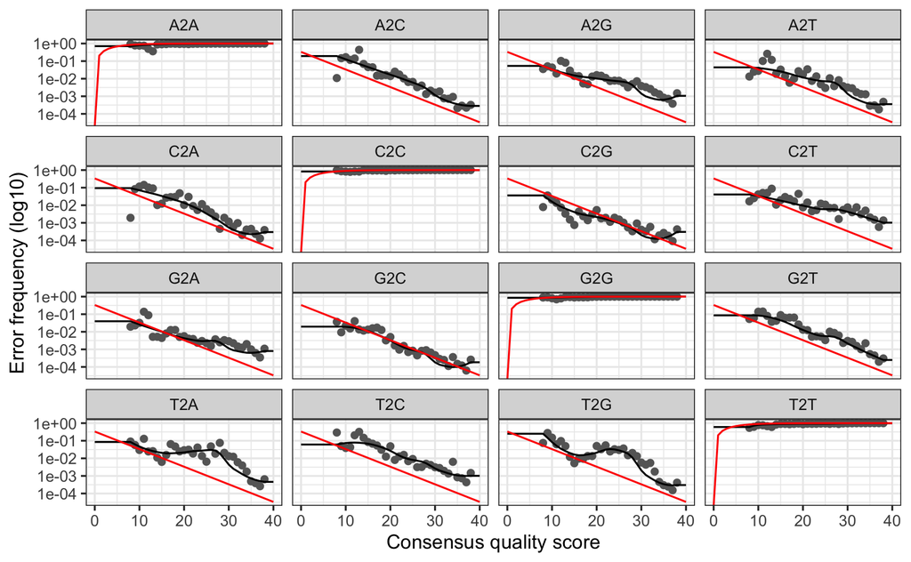

```r
plotErrors(errF, nominalQ=TRUE)
```

Wisdoms from Mike: DADA2 uses our own data (dots) to calculate error rates (model = black line). Sometimes the expected error based on the nominal definition of Q-score (red line) matches error seen in our data. But often, we have a higher error rate and DADA2 will use this.

More sequencing data is more info for the model. A good fit between model and observed data (black line and dots) means We now have good understanding of error rates in our data!

```r
dadaFs <- dada(filtFs, err=errF, multithread=TRUE)
```

```r
dadaRs <- dada(filtRs, err=errR, multithread=TRUE)
```

```r
dadaFs[[1]]
```

```
dada-class: object describing DADA2 denoising results
489 sequence variants were inferred from 38609 input unique sequences.
Key parameters: OMEGA_A = 1e-40, OMEGA_C = 1e-40, BAND_SIZE = 16
```

Notes from DADA2 tutorial: The DADA2 algorithm inferred 489 true sequence variants from the 38609 unique sequences in the first sample. There is much more to the dada-class return object than this (see help(“dada-class”) for some info), including multiple diagnostics about the quality of each denoised sequence variant.

```r
mergers <- mergePairs(dadaFs, filtFs, dadaRs, filtRs, verbose=TRUE)
```

```
39688 paired-reads (in 3124 unique pairings) successfully merged out of 144470 (in 7066 pairings) input.
190111 paired-reads (in 14806 unique pairings) successfully merged out of 214943 (in 21542 pairings) input.
138234 paired-reads (in 11883 unique pairings) successfully merged out of 227153 (in 20791 pairings) input.
73224 paired-reads (in 6417 unique pairings) successfully merged out of 154135 (in 11343 pairings) input.
198565 paired-reads (in 17778 unique pairings) successfully merged out of 232545 (in 30451 pairings) input.
189052 paired-reads (in 18375 unique pairings) successfully merged out of 228263 (in 32912 pairings) input.
52722 paired-reads (in 4133 unique pairings) successfully merged out of 149749 (in 8878 pairings) input.
163840 paired-reads (in 12482 unique pairings) successfully merged out of 202422 (in 19936 pairings) input.
164392 paired-reads (in 11829 unique pairings) successfully merged out of 201950 (in 19128 pairings) input.
108252 paired-reads (in 8508 unique pairings) successfully merged out of 207089 (in 14300 pairings) input.
153115 paired-reads (in 11404 unique pairings) successfully merged out of 257224 (in 17199 pairings) input.
215491 paired-reads (in 12838 unique pairings) successfully merged out of 260444 (in 19972 pairings) input.
175355 paired-reads (in 11449 unique pairings) successfully merged out of 221010 (in 17323 pairings) input.
232634 paired-reads (in 14393 unique pairings) successfully merged out of 253390 (in 22356 pairings) input.
177393 paired-reads (in 11771 unique pairings) successfully merged out of 193797 (in 20056 pairings) input.
175488 paired-reads (in 9250 unique pairings) successfully merged out of 262990 (in 13810 pairings) input.
36255 paired-reads (in 1655 unique pairings) successfully merged out of 42592 (in 3237 pairings) input.
3950 paired-reads (in 372 unique pairings) successfully merged out of 15380 (in 1450 pairings) input.
4 paired-reads (in 2 unique pairings) successfully merged out of 132257 (in 7642 pairings) input.
24710 paired-reads (in 383 unique pairings) successfully merged out of 52837 (in 729 pairings) input.
```

```r
seqtab <- makeSequenceTable(mergers)
dim(seqtab)
```

```
[1]    20 60351
```

```r
table(nchar(getSequences(seqtab)))
```

```
  248   259   283   287   289   290   298   302   348   351   354   393   420   429   439
    1     1     1   338     1     1    18   102     6     1     1     1   311     1  1294
  440   441   442   443   444   445   446   447   450   453   456   457   458   459   460
34289  9347  4307  6436   193     2   585   338     1    31    21  1600    25   270   753
  461
   75
```

```r
seqtab.nochim <- removeBimeraDenovo(seqtab, method="consensus", multithread=TRUE, verbose=TRUE)
```

```
Identified 52128 bimeras out of 60351 input sequences.
```

```r
dim(seqtab.nochim)
```

```
[1]   20 8223
```

```r
sum(seqtab.nochim)/sum(seqtab)
```

```
[1] 0.3842777
```

```r
getN <- function(x) sum(getUniques(x))
track <- cbind(out, sapply(dadaFs, getN), sapply(dadaRs, getN), sapply(mergers, getN), rowSums(seqtab.nochim))
# If processing a single sample, remove the sapply calls: e.g. replace sapply(dadaFs, getN) with getN(dadaFs)
colnames(track) <- c("input", "filtered", "denoisedF", "denoisedR", "merged", "nonchim")
rownames(track) <- sample.names
head(track)
```

```
       input filtered denoisedF denoisedR merged nonchim
Jen01 190010   147700    145871    146185  39688   18946
Jen02 286951   221598    217845    218523 190111   64623
Jen03 299630   234525    230527    230981 138234   52266
Jen04 202181   158228    156087    156141  73224   32620
Jen05 312366   240911    235982    237282 198565   63194
Jen06 311249   237419    232042    233390 189052   59803
```

```r
write.csv(track, here::here('blue-jam/output', 'dada2', 'track_Oct14.csv'))
```

```r
here('blue-jam/data', 'database') %>% list.files()
```

```
character(0)
```

```r
taxa <- assignTaxonomy(
  seqtab.nochim,
  here("databases", "silva_nr99_v138.1_train_set.fa.gz"),
  multithread=TRUE
)
```

```r
taxa <- addSpecies(
  taxa,
  here("databases", "silva_species_assignment_v138.1.fa.gz"),
  allowMultiple = TRUE
)
```

```r
taxa.print <- taxa # Removing sequence row names for display only
rownames(taxa.print) <- NULL
head(taxa.print)
```

```
     Kingdom    Phylum       Class        Order            Family
[1,] "Bacteria" "Firmicutes" "Clostridia" "Lachnospirales" "Lachnospiraceae"
[2,] "Bacteria" "Firmicutes" "Clostridia" "Lachnospirales" "Lachnospiraceae"
[3,] "Bacteria" "Firmicutes" "Clostridia" "Lachnospirales" "Lachnospiraceae"
[4,] "Bacteria" "Firmicutes" "Clostridia" "Lachnospirales" "Lachnospiraceae"
[5,] "Bacteria" "Firmicutes" "Clostridia" "Lachnospirales" "Lachnospiraceae"
[6,] "Bacteria" "Firmicutes" "Clostridia" "Lachnospirales" "Lachnospiraceae"
     Genus                           Species
[1,] "Lachnospiraceae NK4A136 group" NA
[2,] "Lachnospiraceae NK4A136 group" NA
[3,] "Lachnospiraceae NK4A136 group" NA
[4,] "Lachnospiraceae NK4A136 group" NA
[5,] "Lachnospiraceae NK4A136 group" NA
[6,] "Lachnospiraceae NK4A136 group" NA
```

```r
unqs.mock <- seqtab.nochim["mock2",]
unqs.mock <- sort(unqs.mock[unqs.mock>0], decreasing=TRUE) # Drop ASVs absent in the Mock
cat("DADA2 inferred", length(unqs.mock), "sample sequences present in the Mock community.\n")
```

[output not shown]

```r
unqs.water <- seqtab.nochim["NTC2",]
unqs.water <- sort(unqs.mock[unqs.water>0], decreasing=TRUE) # Drop ASVs absent in the Mock
cat("DADA2 inferred", length(unqs.water), "sample sequences present in the water control\n")
```

[output not shown]

Hm, how to interpret this?

More ASVs than species in the mock community can arise by having multiple 16S sequences per species. This is something to check from the sequences available from the mock communities.

More ASVs can also arise via contamination. If there is a sequence in the mock as well as in the samples, then this is good evidence of contamination.

```r
mock.ref <- getSequences(file.path(path, "HMP_MOCK.v35.fasta"))
match.ref <- sum(sapply(names(unqs.mock), function(x) any(grepl(x, mock.ref))))
cat("Of those,", sum(match.ref), "were exact matches to the expected reference sequences.\n")
```

Skipped checking that mock community sequences were exact matches to expected reference sequences because the files associated with our community are currently available in a different format.

```r
saveRDS(seqtab.nochim,file=here("blue-jam/output","dada2_20211014","seqtable_nochimeras_oct14.rds"))
saveRDS(seqtab,file=here("blue-jam/output","dada2_20211014","seqtable_oct14.rds"))
saveRDS(taxa,file=here("blue-jam/output","dada2_20211014","taxonomic_assignments_oct14.rds"))
```